# Tugas Praktikum: Regresi dan Penanganan Otokorelasi Sisaan

Metode Cochrane-Orcutt dan Hildreth-Lu

Abdul Rossyid Pratama

31 August 2026

# 1 Pendahuluan

Laporan ini melakukan pemodelan regresi terhadap dua data yang **dianggap sebagai data cross section**, kemudian memeriksa apakah terdapat otokorelasi pada sisaan model menggunakan plot sisaan dan uji Durbin-Watson. Jika ditemukan otokorelasi, dilakukan penanganan menggunakan metode **Cochrane-Orcutt** dan **Hildreth-Lu**.

# 2 Fungsi yang Digunakan

```r
cochrane_orcutt <- function(x, y, tol = 1e-6, max_iter = 100) {
  model <- lm(y ~ x)
  resid_e <- resid(model)
  rho_old <- 0
  for (i in 1:max_iter) {
    n <- length(resid_e)
    rho <- sum(resid_e[-1] * resid_e[-n]) / sum(resid_e[-n]^2)
    y_star <- y[-1] - rho * y[-length(y)]
    x_star <- x[-1] - rho * x[-length(x)]
    fit_star <- lm(y_star ~ x_star)
    b0 <- coef(fit_star)[1] / (1 - rho)
    b1 <- coef(fit_star)[2]
    resid_e <- y - (b0 + b1 * x)
    if (abs(rho - rho_old) < tol) break
    rho_old <- rho
  }
  list(rho = rho, b0 = as.numeric(b0), b1 = as.numeric(b1),
       iterasi = i, dw_transformed = dwtest(fit_star)$statistic,
       fit_transformed = fit_star)
}

hildreth_lu <- function(x, y, rho_seq = seq(-0.99, 0.99, by = 0.001)) {
  best_sse <- Inf
  best_rho <- NA
  for (rho in rho_seq) {
    y_star <- y[-1] - rho * y[-length(y)]
    x_star <- x[-1] - rho * x[-length(x)]
    fit <- lm(y_star ~ x_star)
    sse <- sum(resid(fit)^2)
    if (sse < best_sse) {
      best_sse <- sse
      best_rho <- rho
    }
  }
  y_star <- y[-1] - best_rho * y[-length(y)]
  x_star <- x[-1] - best_rho * x[-length(x)]
  fit_best <- lm(y_star ~ x_star)
  b0 <- coef(fit_best)[1] / (1 - best_rho)
  b1 <- coef(fit_best)[2]
  list(rho = best_rho, sse = best_sse, b0 = b0, b1 = b1,
       dw_transformed = dwtest(fit_best)$statistic)
}

analisis_otokorelasi <- function(x, y, nama_x, nama_y) {
  model <- lm(y ~ x)
  dw <- dwtest(model)
  co <- cochrane_orcutt(x, y)
  hl <- hildreth_lu(x, y)
  list(model = model, dw = dw, co = co, hl = hl)
}
```

# 3 Dataset 1: Market Share ~ Price

## 3.1 Data

```r
price <- c(0.97,0.95,0.99,0.91,0.98,0.90,0.89,0.86,0.85,0.82,
           0.79,0.83,0.81,0.77,0.76,0.80,0.83,0.79,0.76,0.78)
market_share <- c(3.63,4.20,3.33,4.54,2.89,4.87,4.90,5.29,6.18,7.20,
                   7.25,6.09,6.80,8.65,8.43,8.29,7.18,7.90,8.45,8.23)
hasil1 <- analisis_otokorelasi(price, market_share, "Price", "Market Share")
```

## 3.2 Model Regresi OLS Awal

```r
summary(hasil1$model)
```

```
##
## Call:
## lm(formula = y ~ x)
##
## Residuals:
##      Min       1Q   Median       3Q      Max
## -0.73068 -0.29764 -0.00966  0.30224  0.81193
##
## Coefficients:
##             Estimate Std. Error t value Pr(>|t|)
## (Intercept)   26.910      1.110   24.25 3.39e-15 ***
## x            -24.290      1.298  -18.72 3.02e-13 ***
## ---
## Signif. codes:  0 '***' 0.001 '**' 0.01 '*' 0.05 '.' 0.1 ' ' 1
##
## Residual standard error: 0.4287 on 18 degrees of freedom
## Multiple R-squared:  0.9511, Adjusted R-squared:  0.9484
## F-statistic: 350.3 on 1 and 18 DF,  p-value: 3.019e-13
```

## 3.3 Plot Sisaan

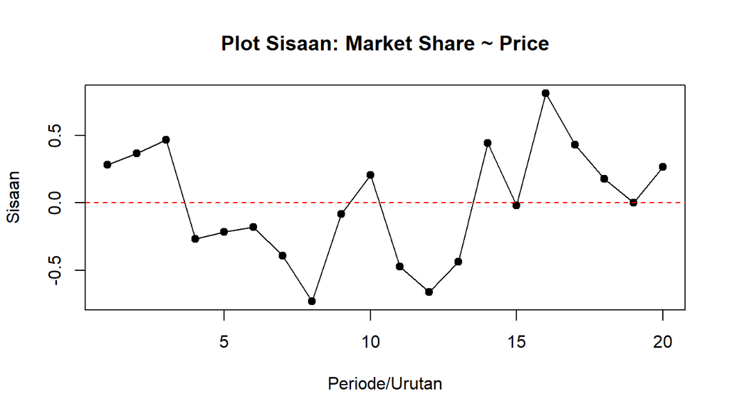

```r
plot(resid(hasil1$model), type = "o", pch = 19,
     main = "Plot Sisaan: Market Share ~ Price",
     xlab = "Periode/Urutan", ylab = "Sisaan")
abline(h = 0, col = "red", lty = 2)
```

Sisaan pada plot di atas tidak menyebar acak, terlihat pola pergerakan yang cenderung berkelompok — mengindikasikan adanya otokorelasi.

## 3.4 Uji Durbin-Watson

```r
hasil1$dw
```

```
##
##  Durbin-Watson test
##
## data:  model
## DW = 1.1358, p-value = 0.009813
## alternative hypothesis: true autocorrelation is greater than 0
```

Dengan n = 20 dan k = 1 (α = 0.05), nilai DW = 1.136 berada **di bawah dL** pada tabel Durbin-Watson, sehingga disimpulkan **terdapat otokorelasi positif** pada sisaan model.

## 3.5 Penanganan: Cochrane-Orcutt

```r
cat("rho          :", hasil1$co$rho, "\n")
```

```
## rho          : 0.4252321
```

```r
cat("Iterasi      :", hasil1$co$iterasi, "\n")
```

```
## Iterasi      : 7
```

```r
cat("Model akhir  : Market Share =", round(hasil1$co$b0, 4), "+", round(hasil1$co$b1, 4), "* Price\n")
```

```
## Model akhir  : Market Share = 26.7221 + -24.0841 * Price
```

```r
cat("DW (transformed):", hasil1$co$dw_transformed, "\n")
```

```
## DW (transformed): 1.958041
```

## 3.6 Penanganan: Hildreth-Lu

```r
cat("rho optimum  :", hasil1$hl$rho, "\n")
```

```
## rho optimum  : 0.425
```

```r
cat("SSE minimum  :", round(hasil1$hl$sse, 4), "\n")
```

```
## SSE minimum  : 2.6594
```

```r
cat("Model akhir  : Market Share =", round(hasil1$hl$b0, 4), "+", round(hasil1$hl$b1, 4), "* Price\n")
```

```
## Model akhir  : Market Share = 26.7227 + -24.0848 * Price
```

```r
cat("DW (transformed):", hasil1$hl$dw_transformed, "\n")
```

```
## DW (transformed): 1.957673
```

## 3.7 Kesimpulan Dataset 1

Kedua metode penanganan menghasilkan nilai ρ yang hampir identik (≈ 0.425) dengan model akhir yang serupa. Setelah koreksi, nilai DW naik dari 1.136 menjadi sekitar 1.958, mendekati 2 — menandakan otokorelasi pada sisaan berhasil ditangani.

# 4 Dataset 2: Sales ~ Advertising

## 4.1 Data

```r
advertising <- c(9.4,9.6,10,10.4,10.8,10.9,11.7,12.2,12.5,12.9,
                  13.0,13.2,13.8,14.2,14.6,14.4,15.0,15.4,15.7,15.9,
                  15.9,16.0,16.3,16.2,16.8,17.3,17.6,18.1,18.3,18.5,
                  18.7,18.9,19.2,20.0,20.0,20.3,20.4,21.0,21.5,22.1)
sales <- c(11.7,12.0,12.3,12.8,13.1,13.6,13.9,14.4,14.7,15.3,
           15.5,15.8,16.1,16.6,16.9,16.7,16.9,17.4,17.6,17.9,
           18.0,17.9,18.0,18.2,18.2,18.3,18.6,19.2,19.3,19.5,
           19.2,19.3,19.5,20.0,20.0,19.9,19.8,19.9,20.2,21.0)
hasil2 <- analisis_otokorelasi(advertising, sales, "Advertising", "Sales")
```

## 4.2 Model Regresi OLS Awal

```r
summary(hasil2$model)
```

```
##
## Call:
## lm(formula = y ~ x)
##
## Residuals:
##      Min       1Q   Median       3Q      Max
## -1.03758 -0.40343  0.08933  0.45674  0.74036
##
## Coefficients:
##             Estimate Std. Error t value Pr(>|t|)
## (Intercept)  5.96513    0.38092   15.66   <2e-16 ***
## x            0.71035    0.02365   30.04   <2e-16 ***
## ---
## Signif. codes:  0 '***' 0.001 '**' 0.01 '*' 0.05 '.' 0.1 ' ' 1
##
## Residual standard error: 0.527 on 38 degrees of freedom
## Multiple R-squared:  0.9596, Adjusted R-squared:  0.9585
## F-statistic: 902.3 on 1 and 38 DF,  p-value: < 2.2e-16
```

## 4.3 Plot Sisaan

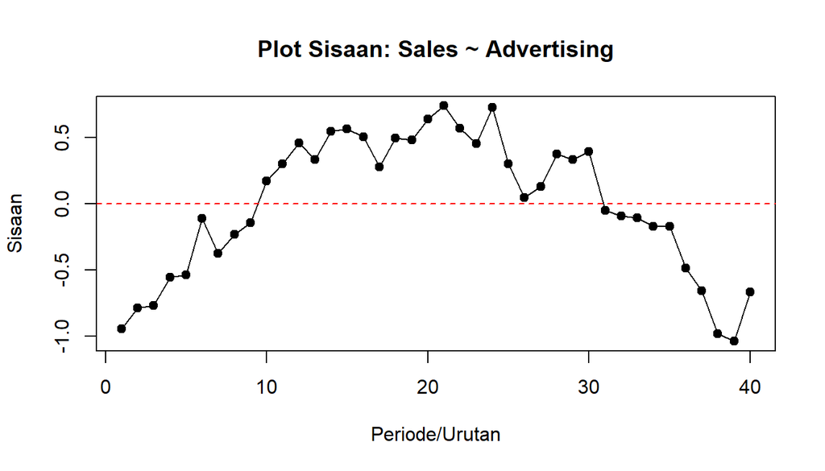

```r
plot(resid(hasil2$model), type = "o", pch = 19,
     main = "Plot Sisaan: Sales ~ Advertising",
     xlab = "Periode/Urutan", ylab = "Sisaan")
abline(h = 0, col = "red", lty = 2)
```

Plot sisaan menunjukkan pola gelombang yang jelas (naik kemudian turun secara bertahap), bukan sebaran acak — indikasi kuat adanya otokorelasi.

## 4.4 Uji Durbin-Watson

```r
hasil2$dw
```

```
##
##  Durbin-Watson test
##
## data:  model
## DW = 0.16204, p-value < 2.2e-16
## alternative hypothesis: true autocorrelation is greater than 0
```

Dengan n = 40 dan k = 1 (α = 0.05), nilai DW = 0.162 jauh **di bawah dL**, sehingga disimpulkan **terdapat otokorelasi positif yang kuat** pada sisaan model.

## 4.5 Penanganan: Cochrane-Orcutt

```r
cat("rho          :", hasil2$co$rho, "\n")
```

```
## rho          : 0.9031212
```

```r
cat("Iterasi      :", hasil2$co$iterasi, "\n")
```

```
## Iterasi      : 25
```

```r
cat("Model akhir  : Sales =", round(hasil2$co$b0, 4), "+", round(hasil2$co$b1, 4), "* Advertising\n")
```

```
## Model akhir  : Sales = 10.2523 + 0.4885 * Advertising
```

```r
cat("DW (transformed):", hasil2$co$dw_transformed, "\n")
```

```
## DW (transformed): 1.939255
```

## 4.6 Penanganan: Hildreth-Lu

```r
cat("rho optimum  :", hasil2$hl$rho, "\n")
```

```
## rho optimum  : 0.903
```

```r
cat("SSE minimum  :", round(hasil2$hl$sse, 4), "\n")
```

```
## SSE minimum  : 1.2912
```

```r
cat("Model akhir  : Sales =", round(hasil2$hl$b0, 4), "+", round(hasil2$hl$b1, 4), "* Advertising\n")
```

```
## Model akhir  : Sales = 10.2475 + 0.4887 * Advertising
```

```r
cat("DW (transformed):", hasil2$hl$dw_transformed, "\n")
```

```
## DW (transformed): 1.9393
```

## 4.7 Kesimpulan Dataset 2

Kedua metode kembali menghasilkan ρ yang sama (≈ 0.903). Setelah koreksi, DW naik dari 0.162 menjadi sekitar 1.939, sudah berada di atas dU — otokorelasi berhasil ditangani.

# 5 Ringkasan Keseluruhan

| Dataset | DW awal | Kesimpulan | ρ (CO & HL) | DW setelah koreksi |
| --- | --- | --- | --- | --- |
| Market Share ~ Price | 1.136 | Ada otokorelasi (DW < dL) | 0.425 | 1.958 |
| Sales ~ Advertising | 0.162 | Ada otokorelasi kuat (DW << dL) | 0.903 | 1.939 |

**Catatan:** Nilai kritis dL dan dU perlu dicek langsung dari tabel Durbin-Watson sesuai n dan k = 1 pada referensi praktikum yang digunakan.